# IODS course project

To allow for easier handling of the data in the next steps, we’ll scale the data by subtracting the column means from the corresponding columns and dividing the difference with standard deviation. The Boston dataset contains only numerical variables.

```r
# center and standardize variables
boston_scaled <- scale(Boston)

# summaries of the scaled variables
summary(boston_scaled)
```

```
##       crim                 zn               indus              chas
##  Min.   :-0.419367   Min.   :-0.48724   Min.   :-1.5563   Min.   :-0.2723
##  1st Qu.:-0.410563   1st Qu.:-0.48724   1st Qu.:-0.8668   1st Qu.:-0.2723
##  Median :-0.390280   Median :-0.48724   Median :-0.2109   Median :-0.2723
##  Mean   : 0.000000   Mean   : 0.00000   Mean   : 0.0000   Mean   : 0.0000
##  3rd Qu.: 0.007389   3rd Qu.: 0.04872   3rd Qu.: 1.0150   3rd Qu.:-0.2723
##  Max.   : 9.924110   Max.   : 3.80047   Max.   : 2.4202   Max.   : 3.6648
##       nox                rm               age               dis
##  Min.   :-1.4644   Min.   :-3.8764   Min.   :-2.3331   Min.   :-1.2658
##  1st Qu.:-0.9121   1st Qu.:-0.5681   1st Qu.:-0.8366   1st Qu.:-0.8049
##  Median :-0.1441   Median :-0.1084   Median : 0.3171   Median :-0.2790
##  Mean   : 0.0000   Mean   : 0.0000   Mean   : 0.0000   Mean   : 0.0000
##  3rd Qu.: 0.5981   3rd Qu.: 0.4823   3rd Qu.: 0.9059   3rd Qu.: 0.6617
##  Max.   : 2.7296   Max.   : 3.5515   Max.   : 1.1164   Max.   : 3.9566
##       rad               tax             ptratio            black
##  Min.   :-0.9819   Min.   :-1.3127   Min.   :-2.7047   Min.   :-3.9033
##  1st Qu.:-0.6373   1st Qu.:-0.7668   1st Qu.:-0.4876   1st Qu.: 0.2049
##  Median :-0.5225   Median :-0.4642   Median : 0.2746   Median : 0.3808
##  Mean   : 0.0000   Mean   : 0.0000   Mean   : 0.0000   Mean   : 0.0000
##  3rd Qu.: 1.6596   3rd Qu.: 1.5294   3rd Qu.: 0.8058   3rd Qu.: 0.4332
##  Max.   : 1.6596   Max.   : 1.7964   Max.   : 1.6372   Max.   : 0.4406
##      lstat              medv
##  Min.   :-1.5296   Min.   :-1.9063
##  1st Qu.:-0.7986   1st Qu.:-0.5989
##  Median :-0.1811   Median :-0.1449
##  Mean   : 0.0000   Mean   : 0.0000
##  3rd Qu.: 0.6024   3rd Qu.: 0.2683
##  Max.   : 3.5453   Max.   : 2.9865
```

The scaling affects the data so that all variables are now centered around the mean value of 0. Let’s take a closer look at the scaled variable “crim” which will be shown divided into quantiles, then we removed it from the scaled Boston dataset, and replaced with the categorical variable “crime”:

```r
# change the object to data frame
boston_scaled <- as.data.frame(boston_scaled)

# create a quantile vector of crim and print it
bins <- quantile(boston_scaled$crim)
bins
```

```
##           0%          25%          50%          75%         100%
## -0.419366929 -0.410563278 -0.390280295  0.007389247  9.924109610
```

```r
# create a categorical variable 'crime'
crime <- cut(boston_scaled$crim, breaks = bins, include.lowest = TRUE, label = c("low", "med_low", "med_high", "high"))

# look at the table of the new factor crime
table(crime)
```

```
## crime
##      low  med_low med_high     high
##      127      126      126      127
```

```r
# remove original crim from the dataset
boston_scaled <- dplyr::select(boston_scaled, -crim)

# add the new categorical value to scaled data
boston_scaled <- data.frame(boston_scaled, crime)
```

Now we can divide the data into test and training sets so that 80 % of the data belongs to the training dataset.

```r
# number of rows in the Boston dataset
n <- nrow(boston_scaled)

# choose randomly 80% of the rows
ind <- sample(n,  size = n * 0.8)

# create train set
train <- boston_scaled[ind,]

# create test set  and check the names of the variables
test <- boston_scaled[-ind,]
colnames(test)
```

```
##  [1] "zn"      "indus"   "chas"    "nox"     "rm"      "age"     "dis"
##  [8] "rad"     "tax"     "ptratio" "black"   "lstat"   "medv"    "crime"
```

Next we are going to fit a linear discriminant analysis (LDA) model to the training data. we’ll use the newly created categorical variable “crime” as the target and all other variables as the predictors.

```r
# linear discriminant analysis
lda.fit <- lda(crime ~ ., data = train)

# print the lda.fit object
lda.fit
```

```
## Call:
## lda(crime ~ ., data = train)
##
## Prior probabilities of groups:
##       low   med_low  med_high      high
## 0.2846535 0.2351485 0.2400990 0.2400990
##
## Group means:
##                  zn      indus        chas        nox         rm        age
## low       0.9181978 -0.9295624 -0.13538645 -0.8731946  0.4657870 -0.8573406
## med_low  -0.1225589 -0.2962928  0.01777305 -0.5544986 -0.1196319 -0.3124425
## med_high -0.3793843  0.1737347  0.21473488  0.3395492  0.1326625  0.4356934
## high     -0.4872402  1.0172187 -0.02879709  1.0750387 -0.3390642  0.8204300
##                 dis        rad        tax     ptratio       black       lstat
## low       0.8643734 -0.6892618 -0.7332289 -0.44739097  0.38104495 -0.76466804
## med_low   0.3352181 -0.5454537 -0.4759551 -0.07864883  0.31622197 -0.14018409
## med_high -0.3573809 -0.4467092 -0.3443216 -0.29279449  0.08293608  0.04279428
## high     -0.8412136  1.6371072  1.5133254  0.77958792 -0.74401054  0.85221219
##                 medv
## low       0.53128942
## med_low   0.01119735
## med_high  0.18889606
## high     -0.61010040
##
## Coefficients of linear discriminants:
##                 LD1          LD2          LD3
## zn       0.04995050  0.595678017 -0.921364251
## indus    0.11003660 -0.335939930  0.274950652
## chas    -0.09466380 -0.100705452  0.142719574
## nox      0.34794586 -0.772795528 -1.389912265
## rm      -0.15187972 -0.121269349 -0.270665110
## age      0.18604837 -0.372433212 -0.151336576
## dis      0.03055744 -0.329607656  0.149696273
## rad      3.64067963  0.947019906 -0.009967605
## tax      0.06829448  0.097584710  0.559827043
## ptratio  0.08580502  0.008084345 -0.268966305
## black   -0.08106903  0.023146990  0.119691700
## lstat    0.24568164 -0.318496979  0.305979592
## medv     0.24060782 -0.387367143 -0.177392319
##
## Proportion of trace:
##    LD1    LD2    LD3
## 0.9579 0.0322 0.0100
```

```r
# the function for lda biplot arrows
lda.arrows <- function(x, myscale = 1, arrow_heads = 0.1, color = "red", tex = 0.75, choices = c(1,2)){
  heads <- coef(x)
  arrows(x0 = 0, y0 = 0,
         x1 = myscale * heads[,choices[1]],
         y1 = myscale * heads[,choices[2]], col=color, length = arrow_heads)
  text(myscale * heads[,choices], labels = row.names(heads),
       cex = tex, col=color, pos=3)
}

# target classes as numeric
classes <- as.numeric(train$crime)

# plot the lda results
plot(lda.fit, dimen = 2, col = classes, pch = classes) + title("LDA biplot")
```

```
## integer(0)
```

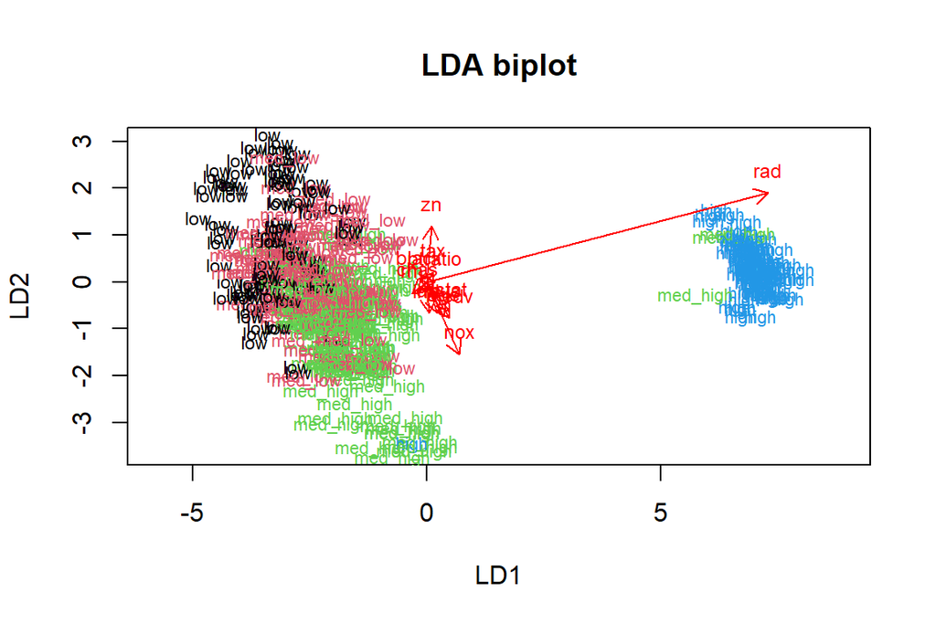

```r
lda.arrows(lda.fit, myscale = 2)
```

To continue testing, we are going to remove the “crime” categorical variable from the test data set. No worries, the crime categories will be saved for later use.

```r
# save the crime classes from test data
correct_classes <- test$crime

# remove the crime variable from test data
test <- dplyr::select(test, -crime)
```

```r
# predict classes with test data
lda.pred <- predict(lda.fit, newdata = test)

# cross tabulate the results
table(correct = correct_classes, predicted = lda.pred$class)
```

```
##           predicted
## correct    low med_low med_high high
##   low        8       4        0    0
##   med_low    7      19        5    0
##   med_high   0       7       19    3
##   high       0       0        0   30
```